# Wykresy, które prezentują podsumowania danych

pogRomcy danych

sezon 2 / odcinek 8  
[Przemysław Biecek @ Uniwersytet Warszawski](http://biecek.pl/)  
Naciśnij `A` by zamienić slajdy na ciągły tekst.  
Naciśnij `T` by wyświetlić spis treści.

# O czym jest ten odcinek?

W poprzednim odcinku na wykresach pokazywaliśmy każdą obserwację / każdy wiersz ze zbioru danych. Informacje o kolejnych wierszach były przedstawiane za pomocą punktów, linii lub napisów.

Jednak, gdy dane są duże i zawierają setki lub setki tysięcy obserwacji, nie sposób przedstawiać każdej z nich osobno. Gdy elementów na wykresie jest zbyt wiele, to wykres zamienia się w wielką plątaninę punktów i krzywych. W takim przypadku często lepszym rozwiązaniem jest przedstawienie podsumowań / statystyk zamiast surowych danych.

W tym odcinku dowiemy się jak graficznie przedstawiać podsumowania danych.

- Jak tworzyć wykresy trendu, przedstawiające wygładzone średnie?
- Jak tworzyć wykresy ramka wąsy / wykresy pudełkowe, przedstawiające pięć liczb Tukeya?
- Jak tworzyć histogram, przedstawiający rozkład wartości?
- Jak tworzyć wykresy słupkowe, przedstawiające liczebności obserwacji?

W tym odcinku będziemy pracować ze zbiorem danych `auta2012`.

# Przygotowanie danych

Zbiór danych o cenach ofertowych używanych aut wykorzystywaliśmy już w pierwszym sezonie. Te dane są szczegółowo opisane w pliku http://pogromcydanych.icm.edu.pl/materials/1_przetwarzanie/0_dane.html

Na potrzeby tego odcinka i prezentowanych tutaj przykładów, do pracy wybierzemy fragment zbioru danych o cenach ofertowych aut. Zawęzimy tutaj naszą uwagę do obserwacji dotyczących Skody Octavii. Ze zbioru kolumn wybierzemy pięć z informacją o roku produkcji, cenie i rodzaju paliwa.

Pełne dane są dostępne w pakiecie `PogromcyDanych`. Będziemy też korzystać z pakietu `dplyr`, który omawialiśmy w pierwszym sezonie. Funkcją `filter()` wybieramy interesujące nas wiersze, a funkcją `select()` interesujące nas kolumny.

```r
library(PogromcyDanych)
skody <- auta2012 %>%
              filter(Marka == 'Skoda', Model == 'Octavia') %>%
              select(Marka, Model, Rok.produkcji, Cena.w.PLN, Rodzaj.paliwa)
head(skody)
```

```
##   Marka   Model Rok.produkcji Cena.w.PLN          Rodzaj.paliwa
## 1 Skoda Octavia          2010      52750                benzyna
## 2 Skoda Octavia          2003      16800 olej napedowy (diesel)
## 3 Skoda Octavia          2007      38900 olej napedowy (diesel)
## 4 Skoda Octavia          2009      39999 olej napedowy (diesel)
## 5 Skoda Octavia          2008      28500 olej napedowy (diesel)
## 6 Skoda Octavia          2008      36800 olej napedowy (diesel)
```

# Geometria `geom_point()` - jednak nie do wszystkiego

Gdy chcemy przedstawić zależność, pomiędzy parą zmiennych, często wykorzystywaną jest geometria punktowa `geom_point()`. Jednak, gdy punktów jest wiele, taka prezentacja może być mało czytelna. W takich przypadkach warto rozważyć geometrię `geom_smooth()` prezentującą wygładzoną lokalną średnią.

Porównajmy zależność pomiędzy ceną samochodu (na rok 2012) a rokiem produkcji. Jeżeli przedstawić te dane za pomocą punktów, to zauważymy, że jakaś zależność jest, ale trudno nam będzie ją dokładnie odczytać. Punktów jest tak wiele, że nakładają się na siebie i trudno się zorientować jakie ceny są typowe dla różnych roczników.

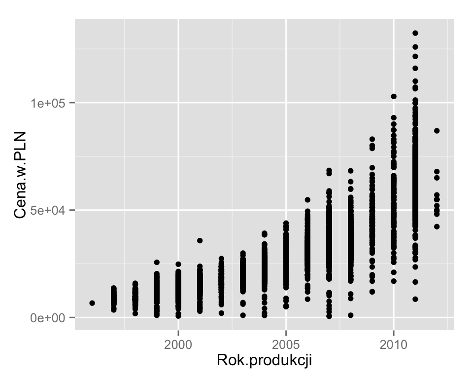

```r
ggplot(skody, aes(x=Rok.produkcji, y = Cena.w.PLN)) +
  geom_point()
```

# Geometria `geom_smooth()` - wykresy trendu

Zastąpienie `geom_point()` przez `geom_smooth()` powoduje, że rysowana jest wygładzona lokalna średnia zamiast punktów.

Jak dokładnie wyznaczana jest ta wygładzana średnia? Jeżeli danych jest mniej niż 1000 obserwacji, to do wygładzania wykorzystywana jest funkcja `loess()` (Local Polynomial Regression Fitting), a jeżeli więcej niż 1000 obserwacji to funkcja `gam()` (Generalized Additive Models). Szczegóły każdej z tych metod można odczytać z plików pomocy dla funkcji `loess()` i `gam()`.

Geometria `geom_smooth()` rysuje również informacje o błędzie standardowym oceny średniej. Szary przedział wokół średniej przedstawia precyzje oszacowania średniej. W miejscach gdzie ta średnia wyznaczana jest na małym zbiorze obserwacji błąd standardowy jest większy, dokładność oceny średniej jest mniejsza.

Jak więc wygląda zależność pomiędzy średnią ceną a rokiem produkcji (ceny na rok 2012)? Nowsze auta są oczywiście droższe.

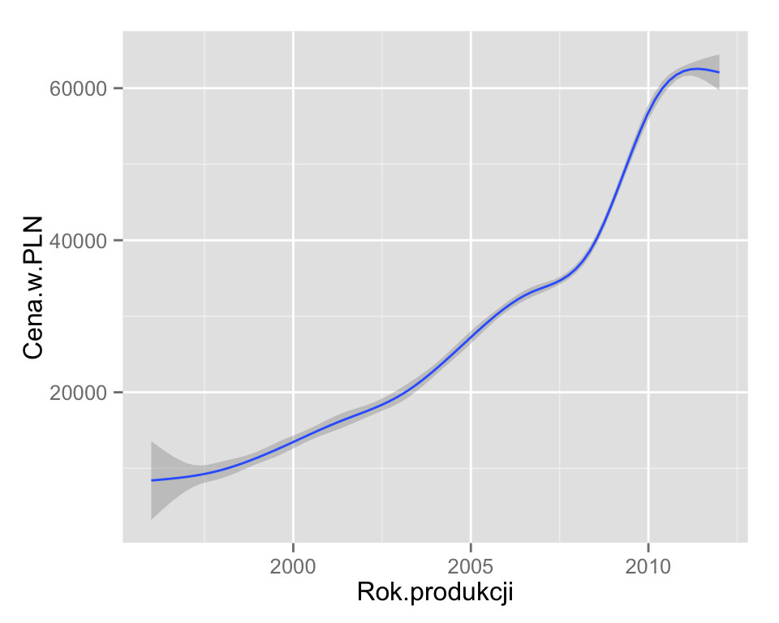

```r
ggplot(skody, aes(x=Rok.produkcji, y = Cena.w.PLN)) +
  geom_smooth()
```

# Geometria `geom_smooth()` - wykresy trendu, błąd standardowy dla średniej

Parametry geometrii `geom_smooth()` przedstawione są na stronie http://docs.ggplot2.org/0.9.3.1/geom_smooth.html.

Zmieniając je możemy uzyskać inne stopnie wygładzania (argument `span` dla `loess`), różną grubość linii, różne modele stosowane do wygładzenia itp.

Jednym z parametrów jest `se`, którym możemy włączać lub wyłączać rysowanie błędów standardowych. Często interesuje nas wyłącznie trend. Dodatkowe przedziały jedynie zaśmiecają wykres. Można je wyłączyć dopisując argument `se=FALSE`.

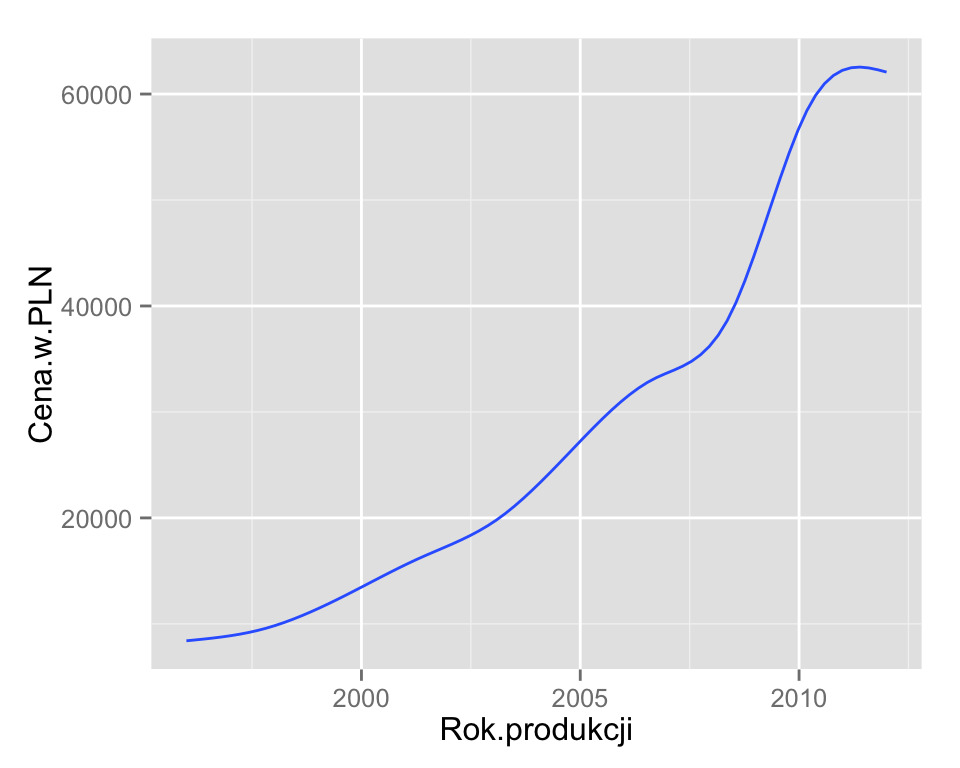

```r
ggplot(skody, aes(x=Rok.produkcji, y = Cena.w.PLN)) +
  geom_smooth(se=FALSE)
```

# Geometria `geom_smooth()` - składanie warstw

W pakiecie `ggplot2` możemy składać na jednym wykresie warstwy z różnymi geometriami.

Przykładowo, możemy nałożyć na siebie warstwę pokazującą trendy i warstwę pokazującą pojedyncze punkty. W wielu sytuacjach to bardzo dobry sposób prezentacji. Pokazuje zarówno każdą z obserwacji na drugim planie jak i główny trend na planie pierwszym.

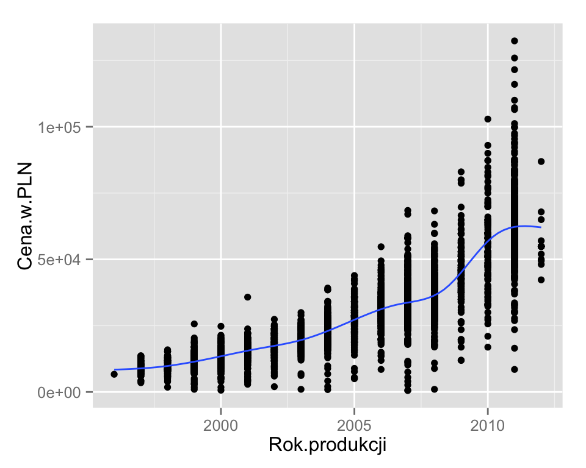

```r
ggplot(skody, aes(x=Rok.produkcji, y=Cena.w.PLN)) +
  geom_point() +
  geom_smooth(se=FALSE)
```

# Geometria `geom_smooth()` - składanie warstw

Mając na wykresie kilka warstw, często chcemy pewne uczynić bardziej wyraźnymi a inne mniej. Dwie cechy najsilniej podkreślające widoczność to wielkość i kolor.

Wykorzystamy cechę `size` aby podkreślić trend a zmniejszyć widoczność warstwy z punktami. Pomniejszmy punkty i powiększmy linię trendu by jeszcze silniej zaznaczyć, która warstwa powinna być bardziej widoczna.

Dla każdej warstwy osobno określamy wielkość linii i punktów argumentem `size`.

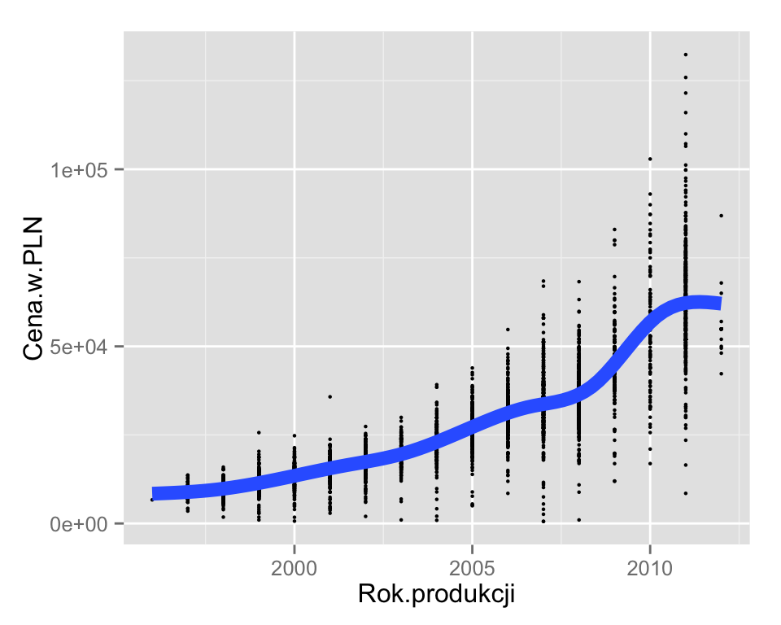

```r
ggplot(skody, aes(x=Rok.produkcji, y=Cena.w.PLN)) +
  geom_point(size=0.8) +
  geom_smooth(se=FALSE, size=3)
```

# Geometria `geom_smooth()` - wykresy trendu

Inną użyteczną opcją geometrii `geom_smooth()` jest możliwość zmiany funkcji wygładzającej. Do wyboru jest między innymi regresja liniowa (parametr `method="lm"`), regresja logistyczna i modele uogólnione (parametr `method="glm"`), regresja odporna (parametr `method="rlm"`) oraz wymieniane już funkcje lokalnie wygładzające (parametr `method="gam"` lub `method="loess"`).

Dla modeli regresyjnych możemy dopasować nie tylko zależność liniową, ale również zależności wielomianowe, wykładnicze czy potęgowe. Opis struktury modelu można wyrazić parametrem `formula`, używając typowego R-owego formatu opisu formuł.

W poniższym przykładzie dodajemy trend kwadratowy do opisu zależności pomiędzy zmiennymi. Argumentem `formula=y~poly(x,2)` określamy trend kwadratowy. Argumentem `method="lm"` określamy sposób liczenia współczynników dla tego trendu.

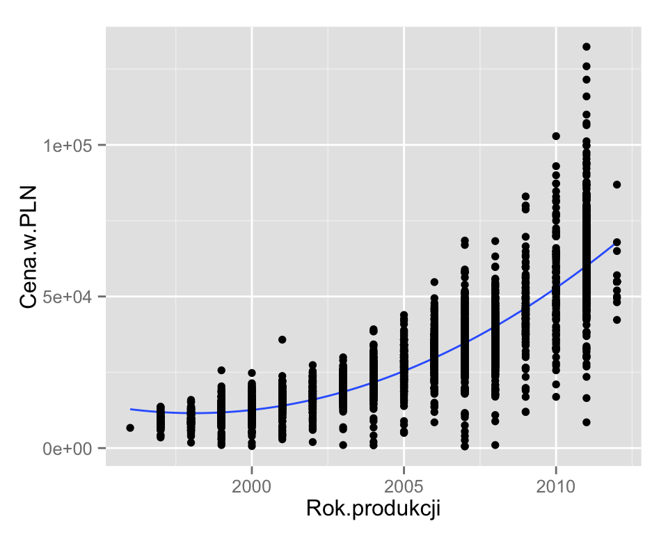

```r
ggplot(skody, aes(x=Rok.produkcji, y=Cena.w.PLN)) +
  geom_smooth(se=FALSE, method="lm", formula=y~poly(x,2)) +
  geom_point()
```

# Geometria `geom_smooth()` - wykresy trendu

Mówiąc o modelach wykładniczych, logarytmicznych lub potęgowych, warto rozważyć jeszcze inną ciekawą opcję, którą oferuje pakiet `ggplot2` - mianowicie transformacje osi.

Funkcje do zarządzania i modyfikacji osi mają prefix `coord_`. Wpisawszy go w RStudio, możemy nacisnąć klawisz TAB aby wyświetliła się lista wszystkich funkcji rozpoczynających się od tego słowa.

Funkcją do transformacji osi jest `coord_trans()`. Możemy jej użyć aby określić czy i jak poszczególne osie mają być transformowane.

Na poniższym przykładzie używamy funkcji `coord_trans()` aby zastosować transformację logarytmiczną dla osi OY.

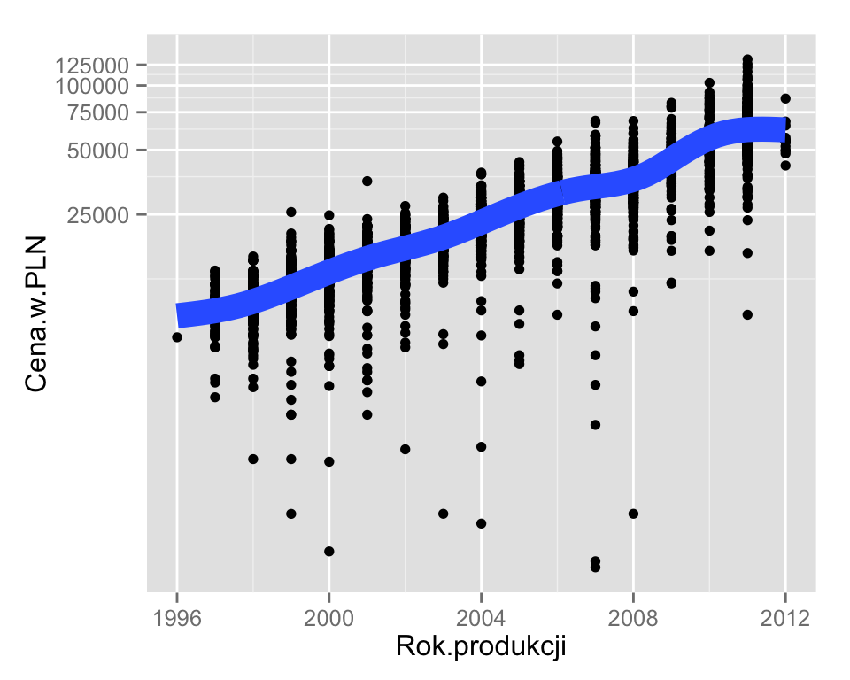

```r
ggplot(skody, aes(x=Rok.produkcji, y = Cena.w.PLN)) +
  geom_point() +
  geom_smooth(se=FALSE, size=5) +
  coord_trans(y = "log10")
```

Na stronie http://docs.ggplot2.org/current/coord_trans.html przedstawiane są najpopularniejsze transformacie, takie jak pierwiastkowa, potęgowa czy logarytmiczna.

# Geometria `geom_smooth()` - wykresy trendu

Bardzo często analizując trend, tak na prawdę nie wiemy z jakim trendem mamy do czynienia. Na wagę złota jest wtedy możliwość porównania różnych trendów na tle danych.

Pakiet `ggplot2` pozwala na tworzenie wykresu przez nakładanie na siebie warstw. Jest to bardzo użyteczne do przedstawienia obok siebie różnych sposobów wyznaczania trendu.

Wykres, który wykonaliśmy przedstawia zależność pomiędzy ceną a rokiem produkcji. Nałóżmy na niego informację o trendzie liniowym, trendzie liczonym algorytmem GAM i trendzie kwadratowym. Każdy z tych trendów narysuje funkcja `geom_sooth()` z określonymi dodatkowymi argumentami.

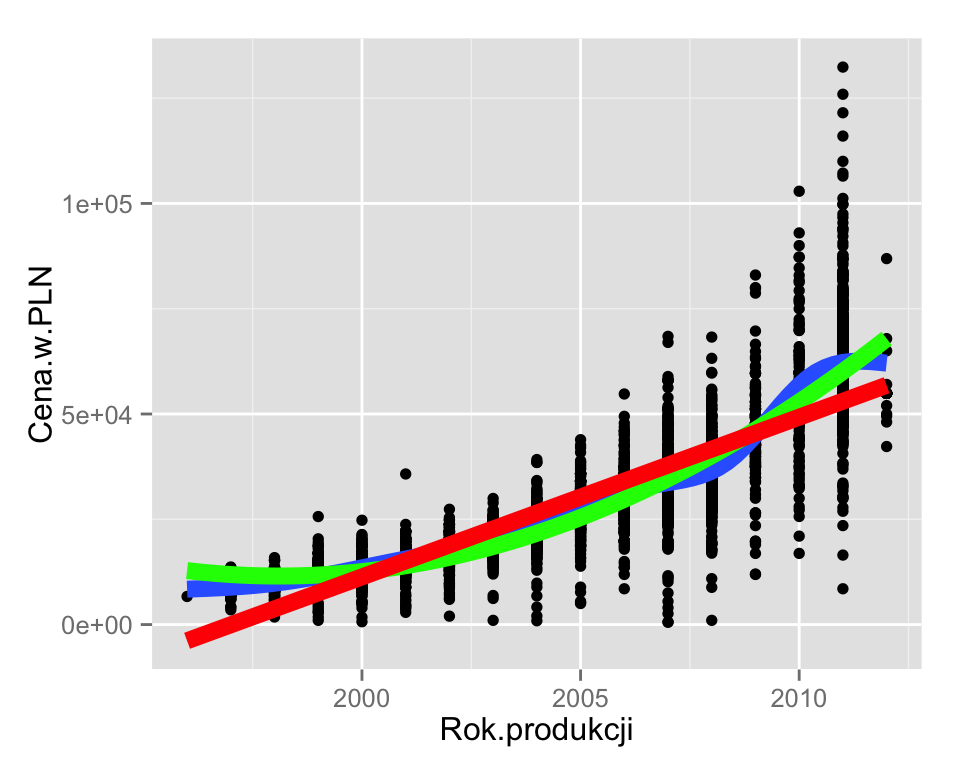

```r
ggplot(skody, aes(x=Rok.produkcji, y = Cena.w.PLN)) +
  geom_point() +
  geom_smooth(se=FALSE, size=3) +
  geom_smooth(method="lm", formula=y~poly(x,2), se=FALSE, size=3, color="green") +
  geom_smooth(method="lm", se=FALSE, size=3, color="red")
```

# Zmienne jakościowe

Geometria `geom_smooth()` była użyteczna do przedstawiania podsumowań dwóch zmiennych ilościowych.

Przyjrzymy się teraz geometriom do prezentowania zależności pomiędzy zmiennymi jakościowymi. Wpierw jednak przygotujmy dane w taki sposób, by mieć ciekawe zmienne do przedstawiania.

Będziemy wciąż korzystać ze zbioru danych z cenami pięcioletnich samochodów marki Skoda, a za zmienne jakościowe wykorzystamy `Model` oraz `Rodzaj.paliwa`.

Ponownie, funkcjami `filter()` i `select()` wybierzemy interesujące nas wiersze i kolumny.

Poprzednio pracowaliśmy z samochodami w modelu `Octavia`, teraz będziemy pracować z autami pięcioletnimi. Stąd drobna zmiana w wywołaniu funkcji `filter()`.

```r
skody <- auta2012 %>%
              filter(Marka == 'Skoda', Rok.produkcji==2007) %>%
              select(Marka, Model, Rok.produkcji, Cena.w.PLN, Rodzaj.paliwa)
head(skody)
```

```
##   Marka   Model Rok.produkcji Cena.w.PLN          Rodzaj.paliwa
## 1 Skoda   Fabia          2007      21850 olej napedowy (diesel)
## 2 Skoda Octavia          2007      38900 olej napedowy (diesel)
## 3 Skoda Octavia          2007      32500 olej napedowy (diesel)
## 4 Skoda Octavia          2007      32500                benzyna
## 5 Skoda  Superb          2007      36600 olej napedowy (diesel)
## 6 Skoda   Fabia          2007      14500 olej napedowy (diesel)
```

# Geometria `geom_point()` ponownie nie daje rady

Czy różne modele pięcioletnich Skód mają różne ceny?

Pewnie tak. Ale jak różne są te średnie ceny oraz na ile są one zróżnicowane? Spróbujmy odpowiedzieć na to pytanie przedstawiając zależność pomiędzy ceną a modelem.

Zauważmy, że geometria `geom_point()` potrafi poradzić sobie z sytuacją, gdy jedna ze zmiennych nie jest zmienną ilościową ale przedstawia nazwę modelu. W poniższym przypadku następuje mapowanie takich wartości jak `Octavia`, `Roomster`, `Superb` na współrzędną x na wykresie. Domyślnie kolejność odpowiada kolejności alfabetycznej nazw tych czynników.

Czy to jednak czytelna prezentacja?

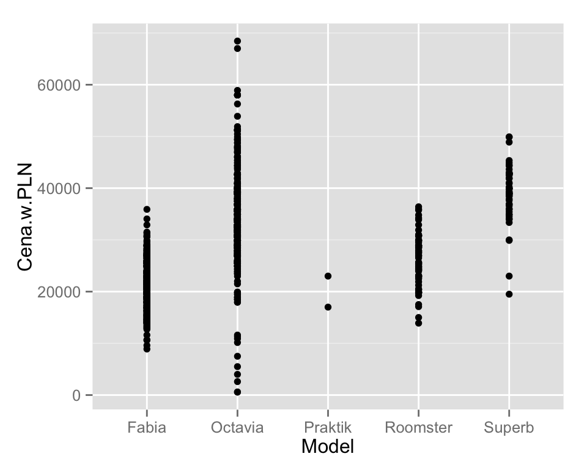

```r
ggplot(skody, aes(x=Model, y = Cena.w.PLN)) +
  geom_point()
```

# Geometria `geom_boxplot()` - wykresy ramka - wąsy

Patrząc na słupki punktów z poprzedniego slajdu trudno oczytać gdzie jest średnia, jaka jest zmienność cen oraz co porównywać pomiędzy modelami. Punktów jest tak dużo, że zlewają się ze sobą.

Do porównywania zmiennej liczbowej pomiędzy grupami, znacznie bardziej nadają się są wykresy pudełko - wąsy, przedstawiające tak zwaną piątkę Tukeya, czyli: minimalną obserwację z grupy, maksymalną, medianę (obserwację środkową) i dwa kwartyle. Te pięć liczb dzieli przedział zmienności cechy na cztery równoliczne przedziały. Od minimalnej wartości do dolnego kwartyla, od dolnego kwartyla do mediany, od mediany do górnego kwartyla i od górnego kwartyla do elementu maksymalnego.

Kwartyle i medianę prezentują dolny i górny brzeg ramki oraz środek ramki. Element minimalny i maksymalny to najniższa i najwyższa wartość na wykresie (odcinek lub punkt). Często najniższy i najwyższy element to odcinek (wąs), ale jeżeli jakieś obserwacje są daleko od brzegu pudełka (dalej niż 1.5 szerokości pudełka) to są one oznaczane osobnym punktem. Po co prezentowane są te punkty? Pomagają one w identyfikowaniu pojedynczych wartości odstających, gdy jedna lub kilka obserwacji jest bardzo daleko od pudełka (pudełko przedstawia środkową połowę obserwacji).

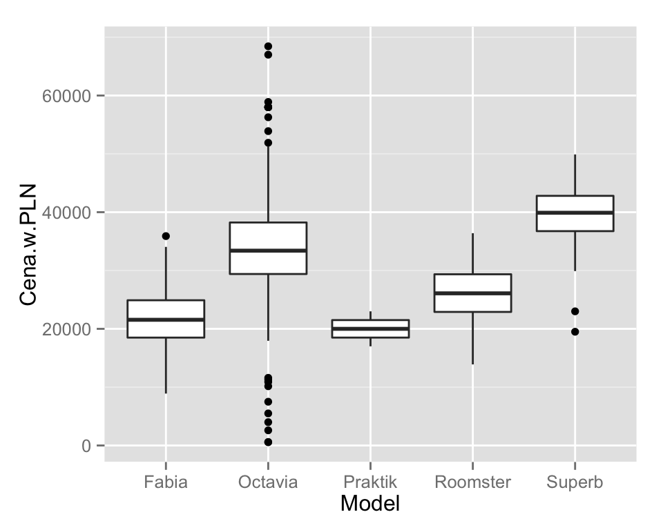

```r
ggplot(skody, aes(x=Model, y = Cena.w.PLN)) +
  geom_boxplot()
```

# Geometria `geom_boxplot()` - wykresy ramka - wąsy

Kolejność na wykresach pudełkowych nie ma znaczenia. Ale często z powodów głównie estetycznych, chcemy uporządkować grupy od największej do najmniejszej. Aby to zrobić na wykresach ramka-wąsy, musimy wcześniej zmienić kolejność grup w zbiorze danych.

Służy do tego funkcja `reorder()`. Jako pierwszy argument przyjmuje wektor ze zmienną grupującą, drugim argumentem jest wektor wartości a trzecim argumentem funkcja. Kolejność grup jest zmieniana tak by odpowiadały kolejności wyników funkcji na tych grupach.

W poniższym przykładzie, poziomy czynnika Model są układane w ten sposób, by odpowiadały medianie (funkcja `median()`) ceny kolejnych modeli.

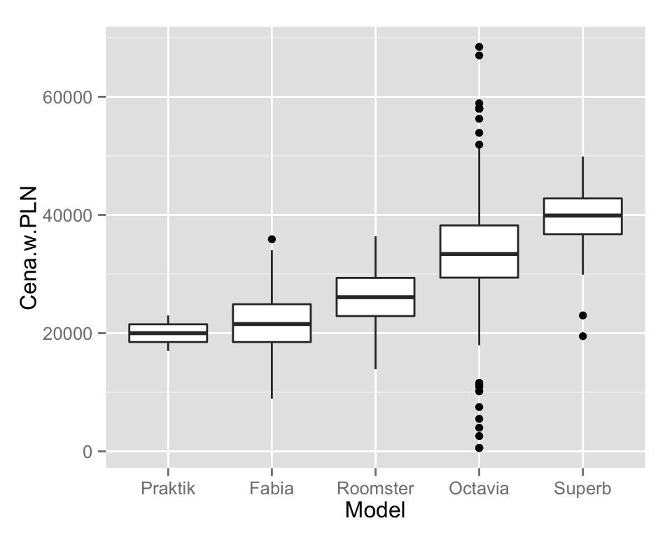

```r
# zmień kolejność modeli z alfabetycznego na związnaego z połówkową ceną
skody$Model <- reorder(skody$Model, skody$Cena.w.PLN, median)
# ta sama instrukcja, prezentuje teraz inny - czytelniejszy wykres
ggplot(skody, aes(x=Model, y = Cena.w.PLN)) +
  geom_boxplot()
```

# Geometria `geom_boxplot()` - wykresy ramka - wąsy

Opis parametrów funkcji `geom_boxplot()` jest przedstawiony na stronie http://docs.ggplot2.org/0.9.3.1/geom_boxplot.html.

Jedną z ciekawszych opcji, pozwalającą na szybkie wyróżnienie określonej grupy na wykresie jest użycie cechy wykresów pudełkowych wraz z kolorem wypełnienia.

Aby wypełnić wykresy pudełkowe różnymi kolorami wystarczy dodać mapowanie `fill=Model` wewnątrz funkcji `aes()`. Wynikiem ubocznym będzie legenda z opisem poszczególnych mapowań.

Same kolory nie wnoszą nowej informacji do wykresu, ale mogą ułatwić odnoszenie się do elementów wykresu. Można bowiem odwoływać się np. do niebieskiego pudełka zamiast mówić o pudełku dla samochodów modelu Skoda Octavia.

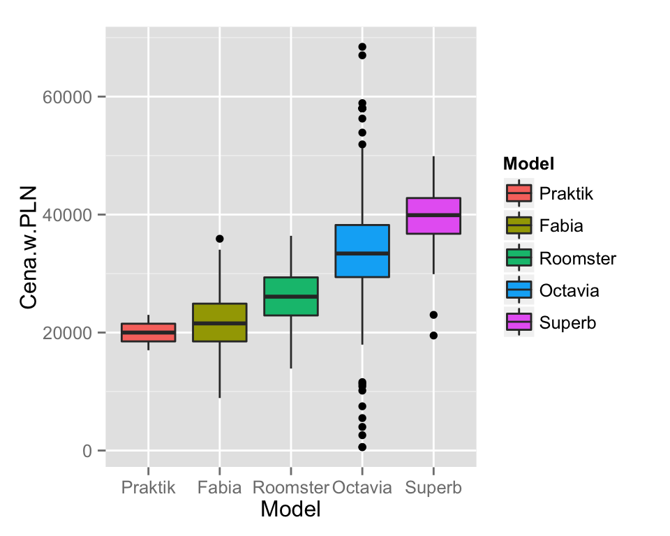

```r
ggplot(skody, aes(x=Model, y = Cena.w.PLN, fill=Model)) +
  geom_boxplot()
```

# Geometria `geom_hist()` - histogram

Wykres ramka - wąsy przedstawia pięć liczb opisujących wartości w grupie. Bardziej szczegółowym opisem, często pozwalającym na lepsze zrozumienie i przedstawienie zmienności w danych, jest histogram.

Histogram za pomocą długości słupków przedstawia liczebności (lub częstości) wartości w określonych przedziałach. Definicja pokrętna, zobaczmy co to oznacza na przykładzie.

Mając wybrane pięcioletnie Skody, zobaczmy jak wygląda zmienność ich ceny.

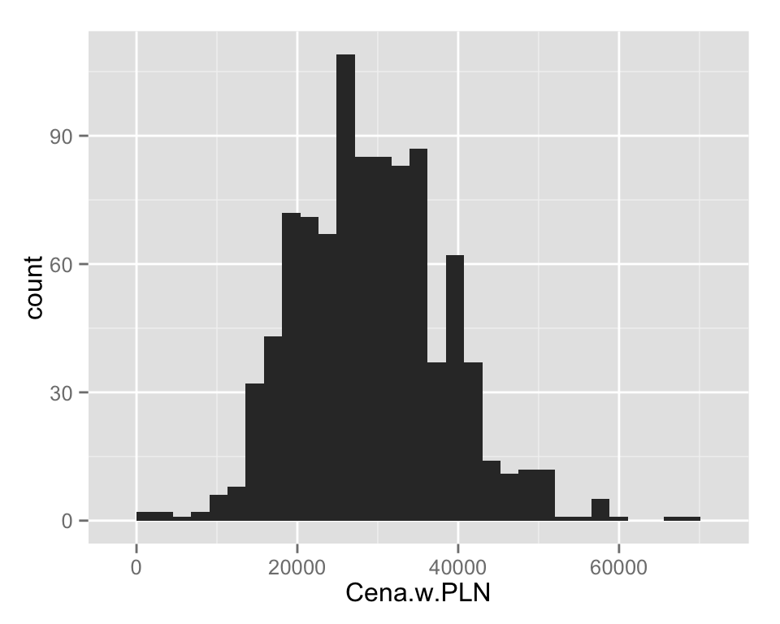

```r
ggplot(skody, aes(x=Cena.w.PLN)) +
  geom_histogram()
```

Funkcja `geom_histogram()` szacuje na ile równie długich przedziałów podzielić zbiór wartości. W tym przypadku cena została podzielona na około 30 przedziałów. Na wykresie przedstawiana jest liczba obserwacji, które zawierają się w określonym odcinku.

Co można dodatkowego odczytać z takiego wykresu? Np. ile jest mniej więcej samochodów w cenie poniżej 20 tysięcy lub powyżej 60 tysięcy. Takiej informacji nie wyciągnęlibyśmy prosto z wykresu pudełko - wąsy.

# Geometria `geom_hist()` - histogram

Prezentując dane za pomocą histogramu duże możliwości daje dodanie informacji o grupach obserwacji. Można to zrobić np. zmieniając kolor wypełnienia, a więc cechę `fill`.

Na poniższym przykładzie kolor wypełnienia oznacza Model samochodu. W danych dla pięcioletnich Skód jest pięć różnych modeli aut. Każdy oznaczono innym kolorem. Wizualnie można teraz nie tylko ocenić w jakich przedziałach cenowych spotkać można najwięcej samochodów danej marki, ale również można oszacować liczbę aut danej marki w określonym przedziale.

Widzimy, że najpopularniejsze są Fabie i Oktavie, zajmują one najwięcej miejsca na wykresie. Dodatkowo cena 30 tysięcy dobrze rozgranicza te dwa modele, Fabie są w większości tańsze a Oktavie droższe.

Aby zwiększyć czytelność poszczególnych grup dodaliśmy do wykresu białe obramowania poszczególnych słupków. Można to zrobić argumentem `color=‘white’.

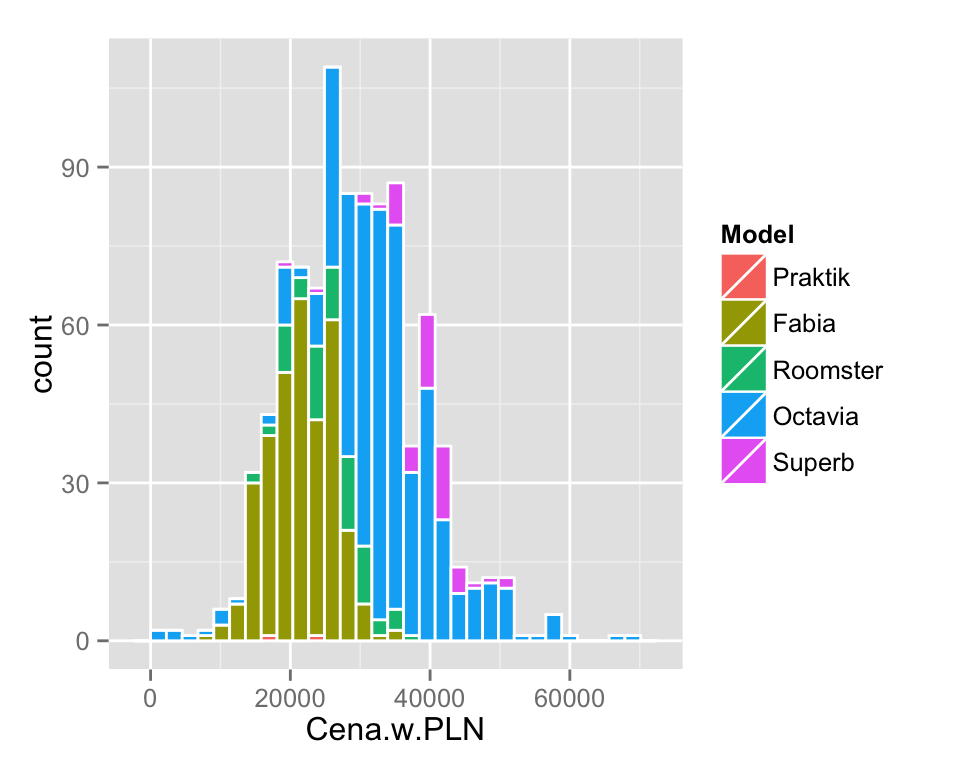

```r
ggplot(skody, aes(x=Cena.w.PLN, fill=Model)) +
  geom_histogram(color='white')
```

# Geometria `geom_bar()` - wykresy słupkowe

Jednym z częściej spotykanych wykresów są wykresy słupkowe. Czas więc i na nie. W pakiecie `ggplot2` można takie wykresy przygotować używając geometrii `geom_bar()`. Zlicza ona liczbę wystąpień poszczególnych grup i przedstawia te liczebności na wykresie za pomocą wysokości słupków.

Zarówno w użyciu jak i w wyglądzie, jest ona bardzo podobna do geometrii `geom_hist()`. To co je najbardziej różni, to że jedna operuje na zmiennych jakościowych (grupach) a inna na zmiennych ilościowych.

W geometrii `geom_bar()` wystarczy wskazać zmienną grupującą. Częstości dla poziomów tej zmiennej wyznaczone będą automatycznie i przedstawione na współrzędnej `y`.

Zobaczmy których modeli Skody jest najwięcej wśród oferowanych 5-letnich aut.

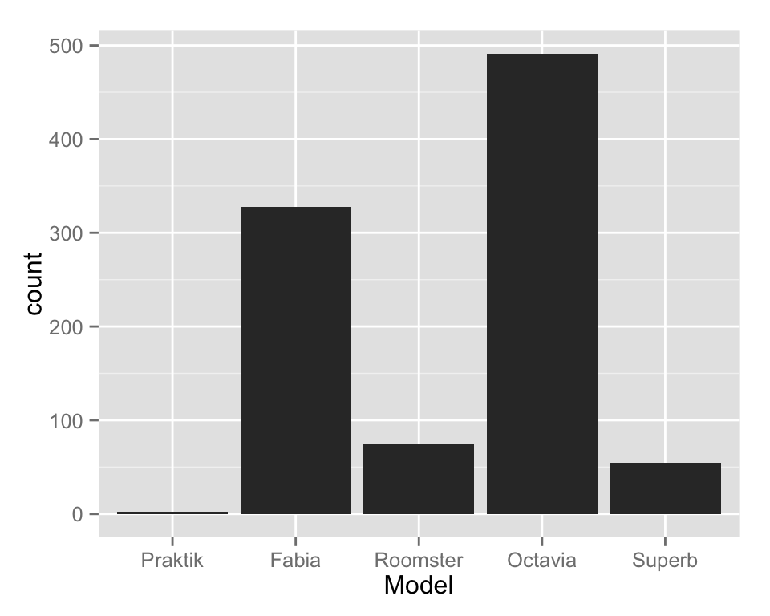

```r
ggplot(skody, aes(x=Model)) +
  geom_bar()
```

# Geometria `geom_bar()` - wykresy słupkowe

Podobnie jak w przypadku histogramu, tak i w przypadku wykresów słupkowych, możemy zaznaczyć na wykresie dodatkową zmienną grupującą. Najczęściej robi się to mapując zmienną grupującą na kolor wypełnienia (cechę `fill`).

Spowoduje to automatyczne dodanie legendy do wykresu. Pozwoli też ocenić udział poszczególnych podgrup w grupach.

Na poniższym przykładzie dodamy informację o rodzaju paliwa. Dodatkowe mapowanie `fill=Rodzaj.paliwa` podzieli słupki na fragmenty o długościach proporcjonalnych do udziału ofert sprzedaży o różnym rodzaju paliwa.

Co ciekawego można z takiego wykresu odczytać? Skód z zainstalowaną instalacją gazową jest niewiele. Jeżeli szukamy samochodu z silnikiem diesla, to częściej można go spotkać u Skody Octavia i Superb niż Fabia czy Roomster.

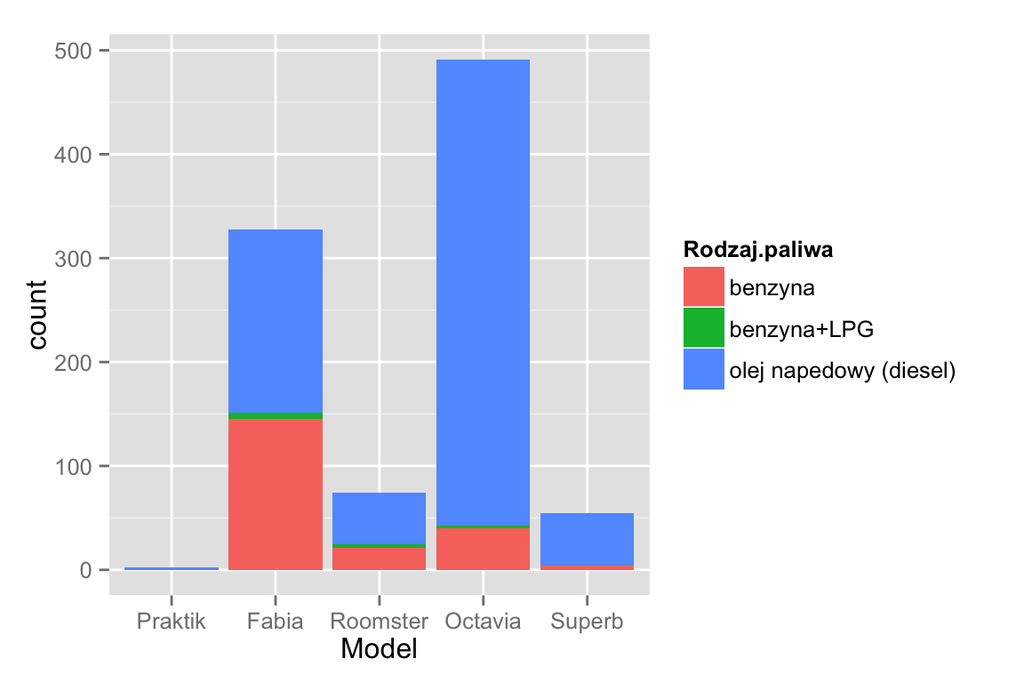

```r
ggplot(skody, aes(x=Model, fill=Rodzaj.paliwa)) +
  geom_bar()
```

# Geometria `geom_bar()` - wykresy słupkowe, wykresy warunkowe

Jak dotąd histogram i wykresy paskowe pokazywały liczebności wierszy w poszczególnych grupach, np. modelach aut.

Gdy jednak zaczynamy umieszczać na wykresie informacje o kolejnych zmiennych, wygodnie jest móc uniezależnić się od wielkości tych grup.

Przykładowo, jeżeli interesuje nas względy udział samochodów z silnikiem diesla, a więc stosunek samochodów zasilanych olejem w grupie Skoda Fabia, do wszystkich samochodów z grupy Skoda Fabia, to musimy istotne liczebności unormować.

Taką normalizację, można w geometrii `geom_bar()` wykonać dodając argument `position="fill"`.

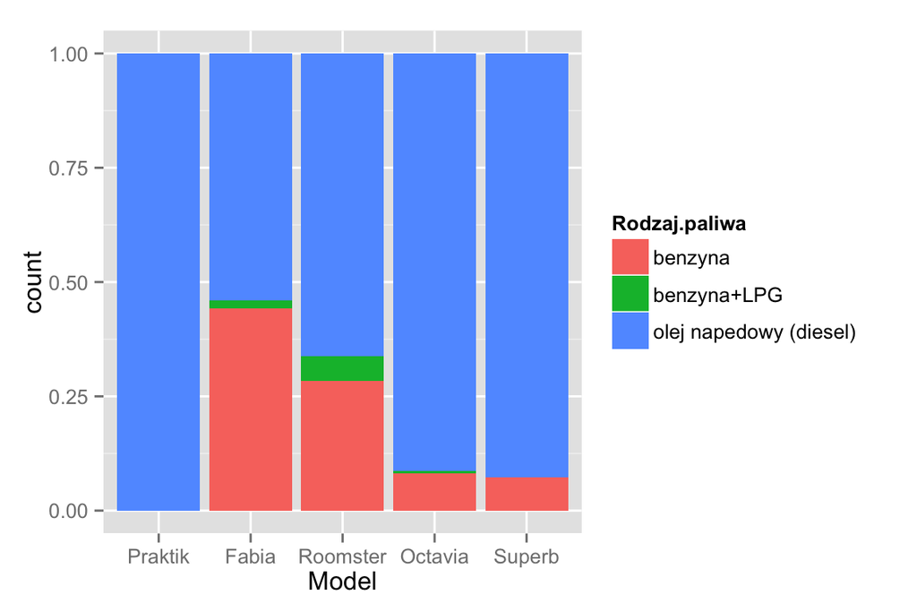

```r
ggplot(skody, aes(x=Model, fill=Rodzaj.paliwa)) +
  geom_bar(position="fill")
```

# A jak policzyć dokładnie liczebności grup?

Wykres pozwala nam na zbudowanie szybkiego wyobrażenia, jak duże są prezentowane wartości.

Ale trudno z niego bardzo dokładnie odczytać wartości liczbowe.

Aby wyliczyć dokładne częstości, możemy wykorzystać poznane w pierwszym sezonie funkcje `group_by()` i `summarise()` z pakietu `dplyr`.

Dla każdej kombinacji grup Model / Rodzaj.pawliwa wyznacz liczbę obserwacji.

```r
skody %>%
  group_by(Model, Rodzaj.paliwa) %>%
  summarise(liczba = n())
```

```
## Source: local data frame [12 x 3]
## Groups: Model
##
##       Model          Rodzaj.paliwa liczba
## 1   Praktik olej napedowy (diesel)      2
## 2     Fabia                benzyna    145
## 3     Fabia            benzyna+LPG      6
## 4     Fabia olej napedowy (diesel)    177
## 5  Roomster                benzyna     21
## 6  Roomster            benzyna+LPG      4
## 7  Roomster olej napedowy (diesel)     49
## 8   Octavia                benzyna     40
## 9   Octavia            benzyna+LPG      3
## 10  Octavia olej napedowy (diesel)    448
## 11   Superb                benzyna      4
## 12   Superb olej napedowy (diesel)     51
```

# Gdzie szukać dalej

Podobnie jak dla poprzedniego odcinka, uzupełnieniem dla opisanych tematów będą następujące pozycje.

- Wiele przydatnych wskazówek można również znaleźć w internetowej książce *,,Cookbook for R’’* http://www.cookbook-r.com/Graphs/
- Więcej informacji o tym jak budować wykresy w pakiecie ggplot2 znaleźć można w rozdziale 4 książki *,,Przewodnik po pakiecie R’’*. Więcej informacji o tej książce http://www.biecek.pl/R/
- Bardzo rozbudowana dokumentacja dla pakietu ggplot2 dostępna jest na stronie *,,ggplot2’’* http://docs.ggplot2.org/current/index.html
- Wiele ciekawych przykładów z użyciem *ggplot2* można znaleźć na stronach http://www.ats.ucla.edu/stat/r/faq/ oraz http://zevross.com/blog/category/r/

# Zadanie, sezon 2, odcinek 8

- Wybierz samochody marki Volkswagen model Passat a następnie narysuj jak średnia cena zależy od roku produkcji za pomocą geometrii `geom_smooth()`.
- Wybierz samochody marki Volkswagen, narysuj jak średnia cena zależy od roku produkcji, różnymi kolorami przedstaw różne modele Volkswagena.
- Wybierz pięcioletnie auta marki Volkswagen i za pomocą wykresu ramka - wąsy przedstaw jak cena auta zależy od modelu.
- Dla wybranych pięcioletnich aut marki Volkswagen przedstaw w podziale na modele jaka część aut ma silnik diesla.

Przykładowe odpowiedzi znajdują się na stronie http://pogromcydanych.icm.edu.pl/materials/2_modelowanie/9_zadania_sezon2.html